# Sparkify Project

```python
# import libraries
from pyspark.sql import SparkSession, Window
from pyspark.sql.functions import udf, col, lit, avg, count, sum, max, min, desc
from pyspark.sql.types import IntegerType, StringType, FloatType

from pyspark.ml import Pipeline
from pyspark.ml.classification import LogisticRegression, RandomForestClassifier, GBTClassifier
from pyspark.ml.evaluation import MulticlassClassificationEvaluator
from pyspark.ml.feature import VectorAssembler, StandardScaler
from pyspark.ml.tuning import ParamGridBuilder, CrossValidator, CrossValidatorModel

import re
import time
import datetime
import numpy as np
import pandas as pd
import matplotlib.pyplot as plt
import seaborn as sns
%matplotlib inline
```

```python
# create a Spark session
spark = SparkSession.builder \
    .master('local') \
    .appName('Sparkify Project') \
    .getOrCreate()
```

# Load and Clean Dataset

In this workspace, the mini-dataset file is `mini_sparkify_event_data.json` (128MB).

There are no missing values in `userID` or `sessionID` but there are empty values in `userID`. I consider them as null and removed them. There are missing values in columns `length`, `artist` and `song`. I filled missing lengths with 0 and missing artists and songs with "None".

After cleaning, the dataset has 225 unique users with 278,154 valid events and 18 columns. The columns are as follows:

- `artist`: artist of the song listened, str
- `auth`: whether the user is logged in, str
- `firstName`: user's first name, str
- `gender`: user's gender, str
- `itemInSession`: item ID in session, int
- `lastName`: user's last name, str
- `length`: duration of an event (usually a song, in seconds), float
- `level`: user's subscription level (free or paid), str
- `location`: user's location, str
- `method`: HTTP method (get or put), str
- `page`: which page user is at (Home, NextSong, Downgrade, etc.), str
- `registration`: timestamp of registration (in milliseconds), int
- `sessionId`: session ID, int
- `song`: song listened, str
- `status`: HTTP return code, int
- `ts`: timestamp of the event (in milliseconds), int
- `userAgent`: browser used by the user, str
- `userID`: user ID, int

```python
data = 'mini_sparkify_event_data.json'
df = spark.read.json(data)
df.printSchema()
```

```
root
 |-- artist: string (nullable = true)
 |-- auth: string (nullable = true)
 |-- firstName: string (nullable = true)
 |-- gender: string (nullable = true)
 |-- itemInSession: long (nullable = true)
 |-- lastName: string (nullable = true)
 |-- length: double (nullable = true)
 |-- level: string (nullable = true)
 |-- location: string (nullable = true)
 |-- method: string (nullable = true)
 |-- page: string (nullable = true)
 |-- registration: long (nullable = true)
 |-- sessionId: long (nullable = true)
 |-- song: string (nullable = true)
 |-- status: long (nullable = true)
 |-- ts: long (nullable = true)
 |-- userAgent: string (nullable = true)
 |-- userId: string (nullable = true)
```

```python
# check number of events
df.count()
```

```
286500
```

```python
# check number of unique userids
df.select('userID').dropDuplicates().count()
```

```
226
```

```python
# df.toPandas()
```

```python
# check unique values of userid
df.select('userId').dropDuplicates().sort('userId').show(5)
```

```
+------+
|userId|
+------+
|      |
|    10|
|   100|
|100001|
|100002|
+------+
only showing top 5 rows
```

```python
# check unique values of sessionid
df.select('sessionId').dropDuplicates().sort('sessionId').show(5)
```

```
+---------+
|sessionId|
+---------+
|        1|
|        2|
|        3|
|        4|
|        5|
+---------+
only showing top 5 rows
```

```python
# keep the events with valid userids
df_valid = df.filter(df.userId != '')
df_valid.count()
```

```
278154
```

```python
# fill missing lengths with 0 and missing artists and songs with "None"
df_valid = df_valid.fillna({'length':0, 'artist':'None', 'song':'None'})
```

Write a scalable script to clean data.

```python
def clean_data(df):
    """
    Clean df

    INPUT:
        df - original df

    OUTPUT:
        df - clean df with valid userids,
             replaced lengths with 0,
             replaced artists and songs with None
    """
    df = df.filter(df.userId != '')
    df = df.fillna({'length':0, 'artist':'None', 'song':'None'})

    return df
```

# Exploratory Data Analysis

### Define Churn

Churn rate is defined as the proportion of individuals discontinuing a service over a specific time period. In this project, I use the event **Cancellation Confirmation** as a flag of churn event. In this mini-dataset, there are 52 churn users and a total of 225 unique users resulting in **23% churn rate**.

```python
# check unique values of page
df_valid.groupby('page').count().sort('page').show()
```

```
+--------------------+------+
|                page| count|
+--------------------+------+
|               About|   495|
|          Add Friend|  4277|
|     Add to Playlist|  6526|
|              Cancel|    52|
|Cancellation Conf...|    52|
|           Downgrade|  2055|
|               Error|   252|
|                Help|  1454|
|                Home| 10082|
|              Logout|  3226|
|            NextSong|228108|
|         Roll Advert|  3933|
|       Save Settings|   310|
|            Settings|  1514|
|    Submit Downgrade|    63|
|      Submit Upgrade|   159|
|         Thumbs Down|  2546|
|           Thumbs Up| 12551|
|             Upgrade|   499|
+--------------------+------+
```

```python
# create a new column churn to label churn users
flag_churn_event = udf(lambda x: 1 if x == 'Cancellation Confirmation' else 0, IntegerType())
df_valid = df_valid.withColumn('churnEvent', flag_churn_event('page'))

windowval = Window.partitionBy('userId')
df_valid = df_valid.withColumn('churn', max('churnEvent').over(windowval))
```

```python
df_valid \
    .select('userId', 'churn').dropDuplicates() \
    .groupby('churn').count().show()
```

```
+-----+-----+
|churn|count|
+-----+-----+
|    1|   52|
|    0|  173|
+-----+-----+
```

```python
52 / 225
```

```
0.2311111111111111
```

### Explore Data

#### Check the timestamp

```python
# convert timestamp to datetime
get_datetime = udf(lambda x: datetime.datetime.fromtimestamp(x/1000).strftime("%m-%d-%Y %H:%M:%S"))
df_valid = df_valid.withColumn('datetime', get_datetime(df_valid.ts))

# check the start date of data collection
df_valid.select('datetime').sort('datetime').take(1)
```

```
[Row(datetime='10-01-2018 00:01:57')]
```

```python
# check the end date of data collection
df_valid.select('datetime').sort(desc('datetime')).take(1)
```

```
[Row(datetime='12-03-2018 01:11:16')]
```

```python
# extract registration month
get_month = udf(lambda x: datetime.datetime.fromtimestamp(x/1000).month, IntegerType())
df_valid = df_valid.withColumn('regMonth', get_month(df_valid.registration))
```

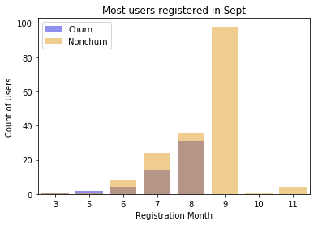

```python
df_month = df_valid.select('userId','churn','regMonth').dropDuplicates().toPandas()

sns.countplot(data=df_month[df_month.churn == 1],
              x='regMonth', alpha=0.5, color='blue', label='Churn')
sns.countplot(data=df_month[df_month.churn == 0],
              x='regMonth', alpha=0.5, color='orange', label='Nonchurn')
plt.xlabel('Registration Month')
plt.ylabel('Count of Users')
plt.title('Most users registered in Sept')
plt.legend();
```

This mini dataset was collected from Oct 1, 2018 to Dec 3, 2018 with 225 unique active users. Most users registered in Sept and only a few registered in Oct and Nov. All churn users registered before Sept.

#### Days being a user

First I created a new column `serviceDays` to indicate the days a user had been using the service.

serviceDays = time of last event - time of registration

```python
df_servicedays = df_valid \
    .select('userId','churn','registration','ts') \
    .withColumn('serviceDays', (df_valid.ts - df_valid.registration)) \
    .groupby('userId','churn').agg({'serviceDays':'max'}) \
    .select('userId','churn',(col('max(serviceDays)')/1000/3600/24).cast('int').alias('serviceDays')) \
    .toPandas()
```

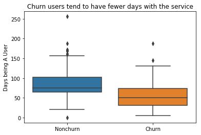

```python
sns.boxplot(data=df_servicedays, x='churn', y='serviceDays')
plt.xlabel('')
plt.xticks([0,1], ['Nonchurn','Churn'])
plt.ylabel('Days being A User')
plt.title('Churn users tend to have fewer days with the service');
```

```python
df_servicedays.groupby('churn').serviceDays.mean()
```

```
churn
0    86.144509
1    56.807692
Name: serviceDays, dtype: float64
```

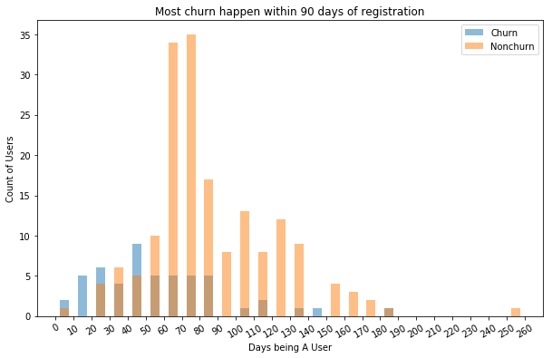

```python
plt.figure(figsize=(10,6))
bins = np.arange(0, df_servicedays.serviceDays.max()+10, 10)
plt.hist(data=df_servicedays[df_servicedays.churn == 1],
         x='serviceDays', bins=bins, rwidth=0.5,
         alpha=0.5, label='Churn')
plt.hist(data=df_servicedays[df_servicedays.churn == 0],
         x='serviceDays', bins=bins, rwidth=0.5,
         alpha=0.5, label='Nonchurn')
plt.xticks(bins, rotation=30)
plt.xlabel('Days being A User')
plt.ylabel('Count of Users')
plt.title('Most churn happen within 90 days of registration')
plt.legend();
```

```python
df_lifetime[(df_lifetime.churn == 1) & (df_lifetime.lifetimeDay < 30)].shape[0] / 52
```

```
0.25
```

```python
df_lifetime[(df_lifetime.churn == 1) & (df_lifetime.lifetimeDay < 60)].shape[0] / 52
```

```
0.5961538461538461
```

```python
df_lifetime[(df_lifetime.churn == 1) & (df_lifetime.lifetimeDay < 90)].shape[0] / 52
```

```
0.8846153846153846
```

According to the figure above, **churn users tend to have fewer days (an average of 57) with the service** while nonchurn users have an average of 86 days. Additionally, 25%, 60% and 88% of churn users churn within 30, 60 and 90 days of registration respectively.

Given that I only have 2 months of data and there are new registered users and churn users, I decide to use **the most recent 10 days of data to predict churn**. For nonchurn users, this means 10 days of data before the last event; for churn users, this means 10 days of data before cancellation. I excluded users with less than 10 days of data including new users who registered in late Nov and churn users who churned within 10 days of registration.

To filter for users with at least 10 days of data, I created a new column `dataRange` to indicate the available days of data:

dataRange = time of last event - time of first event

I also created another new column `countDown` to indicate the countdown days to the last event and filter for the most recent 10 days of data:

countDown = time of last event - time of event

```python
# create a new column dataRange
df_valid = df_valid \
    .withColumn('dataRange', ((max('ts').over(windowval)-min('ts').over(windowval))/1000/3600/24).cast('int'))
```

```python
# create a new column countDown
df_valid = df_valid.withColumn('lastEvent', max('ts').over(windowval))
df_valid = df_valid \
    .withColumn('countDown', ((df_valid.lastEvent-df_valid.ts)/1000/3600/24).cast('int'))
```

```python
# filter data
df_model = df_valid \
    .filter((df_valid.dataRange >= 10) & (df_valid.countDown <= 10))
```

```python
df_model.select('userId','churn').dropDuplicates().groupby('churn').count().show()
```

```
+-----+-----+
|churn|count|
+-----+-----+
|    1|   40|
|    0|  162|
+-----+-----+
```

**In my analysis, I included 202 unique users with 40 churn users**. These users have at least 10 days of data and are active during the most recent 10 days.

Features that may predict churn include:

1. time spent on the service
- number of songs listened
- number of artists listened
- number of songs added to playlist
- number of sessions listened
- number of songs listened per session
- number of friends added
- number of thumbs up
- number of thumbs down
- number of upgrades
- number of downgrades
- number of events as a paid user
- number of ads
- user's gender
- days being a user

Features 1-13 are calculated using the most recent 10 days of data.

#### Time spent on the service: total length of events

```python
df_length = df_model \
    .select('userId','churn','length') \
    .groupby('userId','churn').agg({'length':'sum'}) \
    .withColumnRenamed('sum(length)','length') \
    .select('userId','churn',(col('length')/3600).cast('int').alias('lengthHour')) \
    .toPandas()
```

```python
def box_plot(df, ycol, ylabel, title):
    """
    Visualize a numerical feature using boxplot

    INPUT:
        df - df containing the feature
        ycol - name of column (str)
        ylabel - name of y label (str)
        title - name of title (str)
    """
    sns.boxplot(data=df, x='churn', y=ycol)
    plt.xlabel('')
    plt.xticks([0,1], ['Nonchurn','Churn'])
    plt.ylabel(ylabel)
    plt.title(title);
```

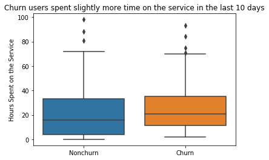

```python
box_plot(df_length, 'lengthHour',
         'Hours Spent on the Service',
         'Churn users spent slightly more time on the service in the last 10 days')
```

#### Number of songs listened

```python
df_song = df_model \
    .select('userId','churn','song').dropDuplicates() \
    .filter((df_model.song != 'None')) \
    .groupby('userId','churn').count() \
    .withColumnRenamed('count','numSong') \
    .toPandas()
```

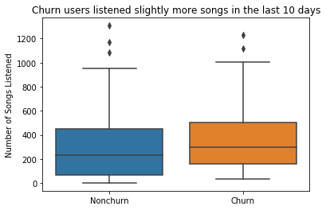

```python
box_plot(df_song, 'numSong',
         'Number of Songs Listened',
         'Churn users listened slightly more songs in the last 10 days')
```

#### Number of artists listened

```python
df_artist = df_model \
    .select('userId','churn','artist').dropDuplicates() \
    .filter((df_model.artist != 'None')) \
    .groupby('userId','churn').count() \
    .withColumnRenamed('count','numArtist') \
    .toPandas()
```

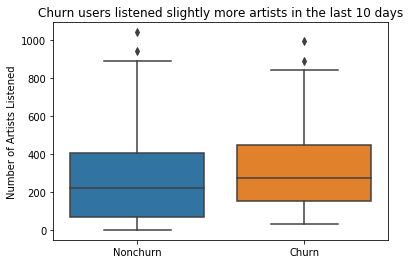

```python
box_plot(df_artist, 'numArtist',
         'Number of Artists Listened',
         'Churn users listened slightly more artists in the last 10 days')
```

#### Number of songs added to playlist

```python
add_song = udf(lambda x: 1 if x == 'Add to Playlist' else 0, IntegerType())
df_model = df_model.withColumn('addSong', add_song('page'))

df_playlist = df_model \
    .select('userId','churn','addSong') \
    .groupby('userId','churn').count() \
    .withColumnRenamed('count','numAddsong') \
    .toPandas()
```

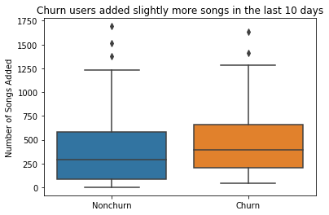

```python
box_plot(df_playlist, 'numAddsong',
         'Number of Songs Added',
         'Churn users added slightly more songs in the last 10 days')
```

#### Number of sessions

```python
df_session = df_model \
    .select('userId','churn','sessionId') \
    .groupby('userId','churn').count() \
    .withColumnRenamed('count','numSession') \
    .toPandas()
```

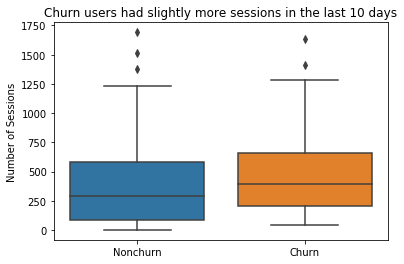

```python
box_plot(df_session, 'numSession',
         'Number of Sessions',
         'Churn users had slightly more sessions in the last 10 days')
```

#### Number of songs listened per session

```python
df_avgsong = df_model \
    .select('userId','churn','page','sessionId') \
    .filter(df_model.page == 'NextSong') \
    .groupby('userId','churn','sessionId').count() \
    .groupby('userId','churn') \
    .agg({'count':'avg'}) \
    .select('userId','churn',col('avg(count)').cast('int').alias('avgSong')) \
    .toPandas()
```

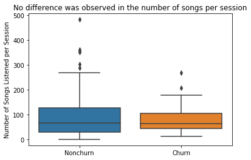

```python
box_plot(df_avgsong, 'avgSong',
         'Number of Songs Listened per Session',
         'No difference was observed in the number of songs per session')
```